# Nora Master Project Data Analysis Notebook

```r
# run chi-squared test
chisq_result <- chisq.test(survey_d6_contingency)
print(chisq_result)
```

```
##
##  Pearson's Chi-squared test
##
## data:  survey_d6_contingency
## X-squared = 28.8, df = 24, p-value = 0.2277
```

Plot proportion bar plot across different groups

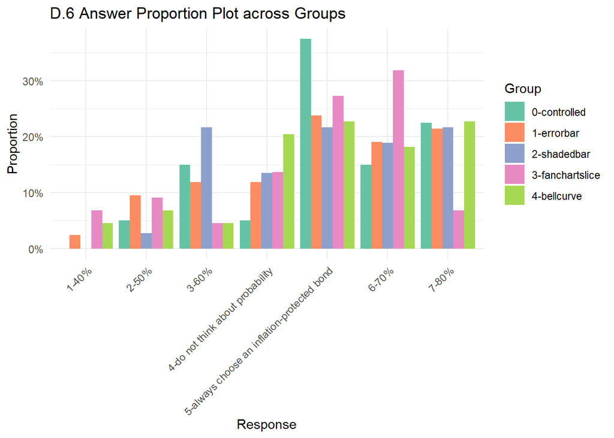

```r
survey_d6_prop  <- as.data.frame(survey_d6_contingency)
# rename columns
names(survey_d6_prop) <- c("D.6", "Group", "Count")
# add a labelled column
survey_d6_prop <- survey_d6_prop %>%
  mutate(D.6_label = case_when(
    D.6 == "1" ~ "1-40%",
    D.6 == "2" ~ "2-50%",
    D.6 == "3" ~ "3-60%",
    D.6 == "4" ~ "4-do not think about probability",
    D.6 == "5" ~ "5-always choose an inflation-protected bond",
    D.6 == "7" ~ "6-70%",
    D.6 == "8" ~ "7-80%"
  ))
# calculate proportions within each group
survey_d6_prop <- survey_d6_prop %>%
  group_by(Group) %>%
  mutate(Proportion = Count / sum(Count))
ggplot(survey_d6_prop, aes(x = as.factor(`D.6_label`), y = Proportion, fill = Group)) + geom_col(position = "dodge") +
  # facet_wrap(~Group)+
  labs(
    title = "D.6 Answer Proportion Plot across Groups",
    x = "Response",
    y = "Proportion"
  ) +
   scale_fill_brewer(palette = "Set2")+
  scale_y_continuous(labels = scales::percent_format(accuracy = 1)) +
  theme_minimal()+
  theme(axis.text.x = element_text(angle = 45, hjust = 1))
```

Plot the histogram including all participants

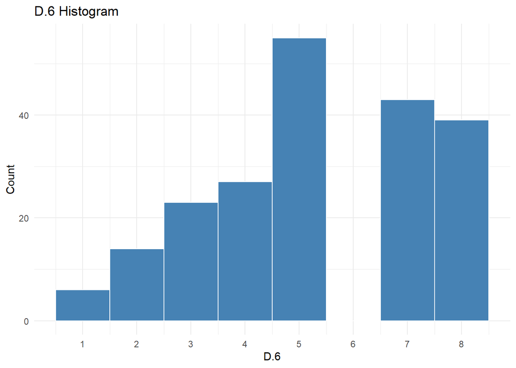

```r
# histogram including all participants
ggplot(survey_d6, aes(x = d6_value)) +
  geom_histogram(binwidth = 1, fill = "steelblue", color = "white") +
  # facet_wrap(~ group) +
  labs(title = "D.6 Histogram",
       x = "D.6",
       y = "Count") +
  scale_x_continuous(breaks = seq(0, max(survey_d6$d6_value, na.rm = TRUE), by = 1)) +
  theme_minimal()
```

## D.7 Considering inflation-protected bond If the probability of inflation being high (> 3%) is greater than the following percentages, I would consider investing in the inflation-protected bond:  
Variable: categorical  
Method: contingency table & chi-squared test  
*Result: Fail to reject the null hypothesis.**

```r
# combine data from different groups
survey_d7 <- data.frame()
survey_d7_list <- list("Q5.7","Q7.7", "Q9.7", "Q11.7", "Q13.7")
for (i in seq_along(group_list)) {
  df <- group_list[[i]]
  col <- survey_d7_list[[i]]
  temp_table <- df[, c(col, "group")]
  names(temp_table) <- c("d7_value", "group")
  survey_d7 <- rbind(survey_d7, temp_table)
}
survey_d7$d7_value <- as.numeric(survey_d7$d7_value)
```

Contingency table

```r
survey_d7_contingency <- table(survey_d7$d7_value, survey_d7$group)
print(survey_d7_contingency)
```

```
##
##     0-controlled 1-errorbar 2-shadedbar 3-fanchartslice 4-bellcurve
##   1            2          0           5               1           0
##   2            3          4           0               6           3
##   3            2          4           6               5           5
##   4            6          1           4               3           4
##   5            1          3           1               4           3
##   7            3          4           7               2           2
##   8            5          1           1               1           0
```

```r
# run chi-squared test
chisq_result <- chisq.test(survey_d7_contingency)
print(chisq_result)
```

```
##
##  Pearson's Chi-squared test
##
## data:  survey_d7_contingency
## X-squared = 35.733, df = 24, p-value = 0.05824
```

Plot proportion bar plot across different groups

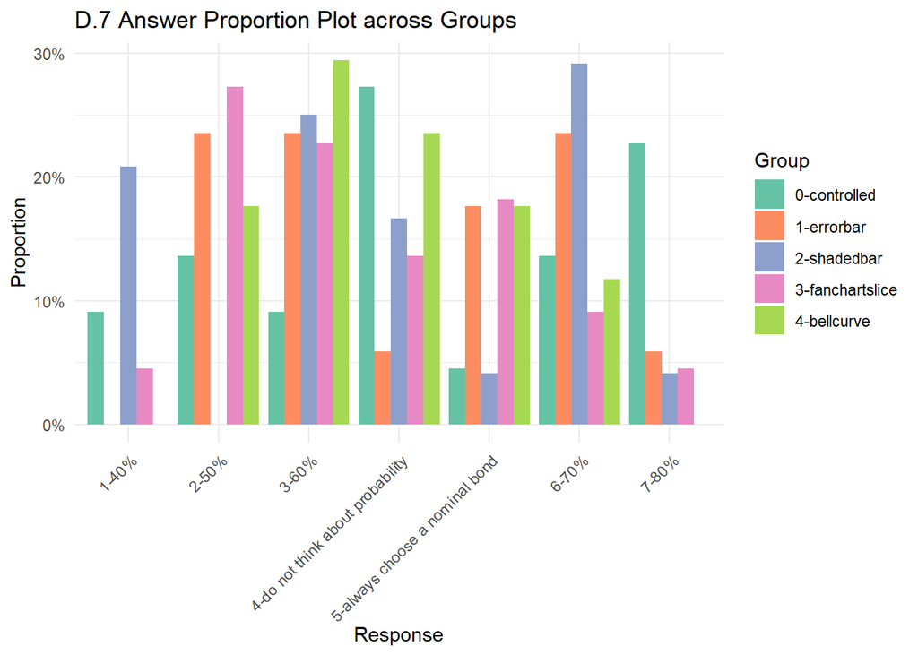

```r
survey_d7_prop  <- as.data.frame(survey_d7_contingency)
# rename columns
names(survey_d7_prop) <- c("D.7", "Group", "Count")
# add a labelled column
survey_d7_prop <- survey_d7_prop %>%
  mutate(D.7_label = case_when(
    D.7 == "1" ~ "1-40%",
    D.7 == "2" ~ "2-50%",
    D.7 == "3" ~ "3-60%",
    D.7 == "4" ~ "4-do not think about probability",
    D.7 == "5" ~ "5-always choose a nominal bond",
    D.7 == "7" ~ "6-70%",
    D.7 == "8" ~ "7-80%"
  ))
# calculate proportions within each group
survey_d7_prop <- survey_d7_prop %>%
  group_by(Group) %>%
  mutate(Proportion = Count / sum(Count))
ggplot(survey_d7_prop, aes(x = as.factor(`D.7_label`), y = Proportion, fill = Group)) + geom_col(position = "dodge") +
  # facet_wrap(~Group)+
  labs(
    title = "D.7 Answer Proportion Plot across Groups",
    x = "Response",
    y = "Proportion"
  ) +
   scale_fill_brewer(palette = "Set2")+
  scale_y_continuous(labels = scales::percent_format(accuracy = 1)) +
  theme_minimal()+
  theme(axis.text.x = element_text(angle = 45, hjust = 1))
```

Plot the histogram including all participants

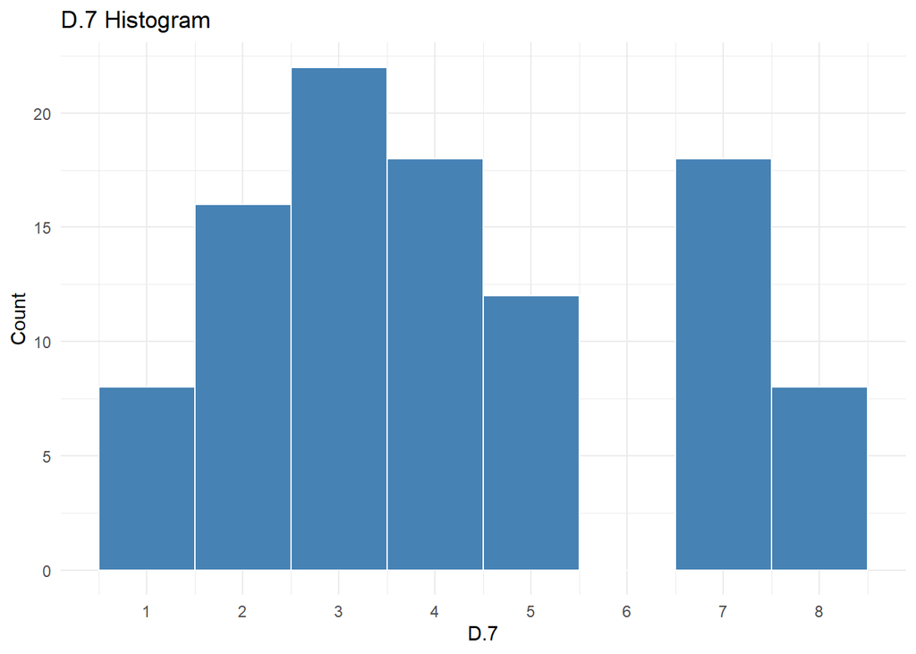

```r
# histogram including all participants
ggplot(survey_d7, aes(x = d7_value)) +
  geom_histogram(binwidth = 1, fill = "steelblue", color = "white") +
  # facet_wrap(~ group) +
  labs(title = "D.7 Histogram",
       x = "D.7",
       y = "Count") +
  scale_x_continuous(breaks = seq(0, max(survey_d7$d7_value, na.rm = TRUE), by = 1)) +
  theme_minimal()
```

## D.8 Impact on Desicion-making Considering the payoff for the Nominal Bond, which of the following has a larger impact on your decision-making?  
Variable: categorical  
Method: contingency table & chi-squared test  
**Result: Fail to reject the null hypothesis.**

```r
# combine data from different groups
survey_d8 <- data.frame()
survey_d8_list <- list("Q5.8","Q7.8", "Q9.8", "Q11.8", "Q13.8")
for (i in seq_along(group_list)) {
  df <- group_list[[i]]
  col <- survey_d8_list[[i]]
  temp_table <- df[, c(col, "group")]
  names(temp_table) <- c("d8_value", "group")
  survey_d8 <- rbind(survey_d8, temp_table)
}
survey_d8$d8_value <- as.numeric(survey_d8$d8_value)
```

Contingency table

```r
survey_d8_contingency <- table(survey_d8$d8_value, survey_d8$group)
print(survey_d8_contingency)
```

```
##
##     0-controlled 1-errorbar 2-shadedbar 3-fanchartslice 4-bellcurve
##   1           33         28          35              43          40
##   2           16         15          19              12          13
##   3           13         16           7              11           8
```

```r
# run chi-squared test
chisq_result <- chisq.test(survey_d8_contingency)
print(chisq_result)
```

```
##
##  Pearson's Chi-squared test
##
## data:  survey_d8_contingency
## X-squared = 10.474, df = 8, p-value = 0.2333
```

Plot proportion bar plot across different groups

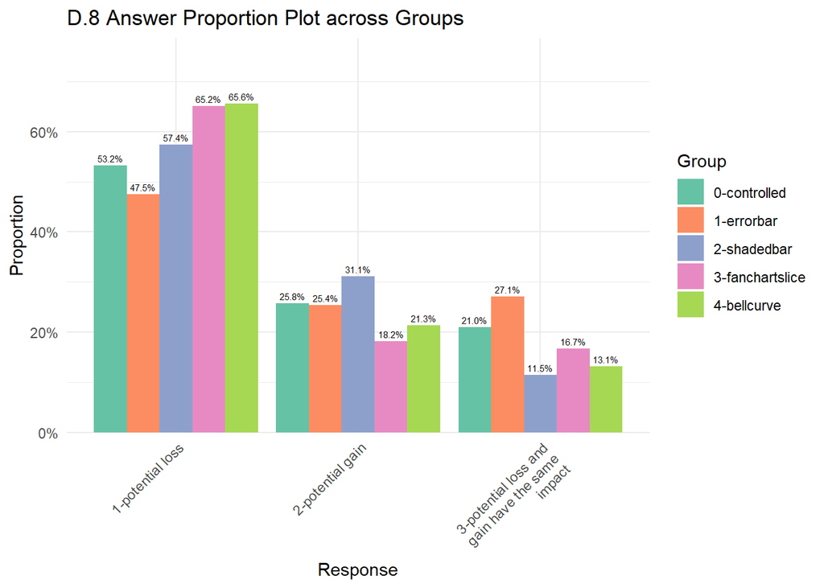

```r
library(stringr)
survey_d8_prop  <- as.data.frame(survey_d8_contingency)
# rename columns
names(survey_d8_prop) <- c("D.8", "Group", "Count")
# add a labelled column
survey_d8_prop <- survey_d8_prop %>%
  mutate(D.8_label = case_when(
    D.8 == "1" ~ "1-potential loss",
    D.8 == "2" ~ "2-potential gain",
    D.8 == "3" ~ "3-potential loss and gain\ have the same impact"
  ))
# calculate proportions within each group
survey_d8_prop <- survey_d8_prop %>%
  group_by(Group) %>%
  mutate(Proportion = Count / sum(Count))
ggplot(survey_d8_prop, aes(x = as.factor(`D.8_label`), y = Proportion, fill = Group)) + geom_col(position = "dodge") +
   scale_x_discrete(labels = function(x) str_wrap(x, 20)) +
  geom_text(aes(label = scales::percent(Proportion, accuracy = 0.1)),
            position = position_dodge(width = 0.9), vjust = -0.5, size = 2) +
  # facet_wrap(~Group)+
  labs(
    title = "D.8 Answer Proportion Plot across Groups",
    x = "Response",
    y = "Proportion"
  ) +
   scale_fill_brewer(palette = "Set2")+
  scale_y_continuous(labels = scales::percent_format(accuracy = 1),
                     expand = expansion(mult = c(0, 0.2)) ) +
  theme_minimal()+
  theme(axis.text.x = element_text(angle = 45, hjust = 1))
```

Plot the histogram including all participants

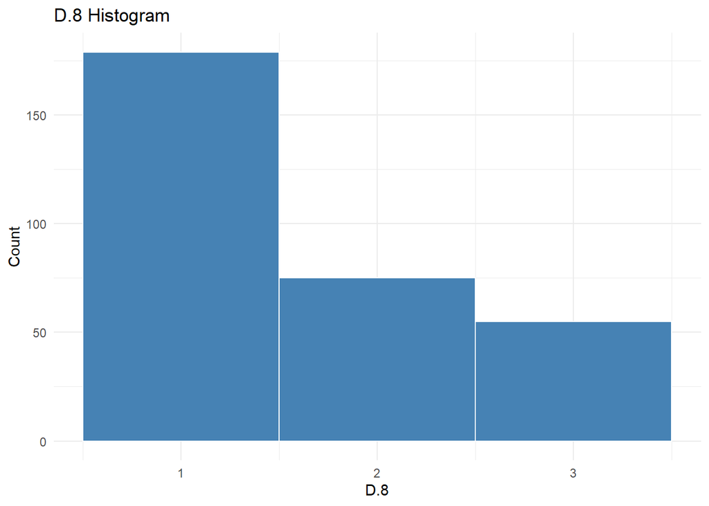

```r
# histogram including all participants
ggplot(survey_d8, aes(x = d8_value)) +
  geom_histogram(binwidth = 1, fill = "steelblue", color = "white") +
  # facet_wrap(~ group) +
  labs(title = "D.8 Histogram",
       x = "D.8",
       y = "Count") +
  scale_x_continuous(breaks = seq(0, max(survey_d8$d8_value, na.rm = TRUE), by = 1)) +
  theme_minimal()
```

## D.9 Effectiveness of the graph for decision-making

On a scale of 1 to 10, where 1 means the forecast was not effective at all and 10 means it was very effective, how effective do you think the forecast was in assisting your decision-making?  
*1-Not effective at all; 10-Very effective*  
Variable: continuous  
Method: ANNOVA test or KW test (depends on whether it’s normally distributed)  
**Result: At least one group is statistically significant than others.**

```r
# combine data from different groups
survey_d9 <- data.frame()
survey_d9_list <- list("Q5.9_1","Q7.9_1", "Q9.9_1", "Q11.9_1", "Q13.9_1")
for (i in seq_along(group_list)) {
  df <- group_list[[i]]
  col <- survey_d9_list[[i]]
  temp_table <- df[, c(col, "group")]
  names(temp_table) <- c("d9_value", "group")
  survey_d9 <- rbind(survey_d9, temp_table)
}
survey_d9$d9_value <- as.numeric(survey_d9$d9_value)
summary(survey_d9$d9_value)
```

```
##    Min. 1st Qu.  Median    Mean 3rd Qu.    Max.
##   1.000   5.000   7.000   6.366   8.000  10.000
```

Statistical test

```r
# Initial Check
# summary(survey_d9$d9_value)
# check normality --> the data is not normally distributed
# shapiro.test(survey_d9$d9_value)

# run Kruskal-Wallis test
kruskal_test <- kruskal.test(d9_value ~ group, data = survey_d9)
print(kruskal_test)
```

```
##
##  Kruskal-Wallis rank sum test
##
## data:  d9_value by group
## Kruskal-Wallis chi-squared = 10.047, df = 4, p-value = 0.03964
```

```r
# Effect size
kw_es  <- kruskal_effsize(d9_value ~ group, data = survey_d9, ci = TRUE)
print(kw_es)
```

```
## # A tibble: 1 × 7
##   .y.          n effsize conf.low conf.high method  magnitude
## * <chr>    <int>   <dbl>    <dbl>     <dbl> <chr>   <ord>
## 1 d9_value   309  0.0199  -0.0034      0.08 eta2[H] small
```

```r
# Post-hoc test
dunnTest(d9_value ~ group, data = survey_d9, method = "bonferroni")
```

```
## Dunn (1964) Kruskal-Wallis multiple comparison
```

```
##   p-values adjusted with the Bonferroni method.
```

```
##                        Comparison          Z    P.unadj     P.adj
## 1       0-controlled - 1-errorbar  0.3166253 0.75152796 1.0000000
## 2      0-controlled - 2-shadedbar  0.7111562 0.47698744 1.0000000
## 3        1-errorbar - 2-shadedbar  0.3869883 0.69876483 1.0000000
## 4  0-controlled - 3-fanchartslice  2.4870900 0.01287928 0.1287928
## 5    1-errorbar - 3-fanchartslice  2.1337039 0.03286703 0.3286703
## 6   2-shadedbar - 3-fanchartslice  1.7545538 0.07933566 0.7933566
## 7      0-controlled - 4-bellcurve  2.1805856 0.02921408 0.2921408
## 8        1-errorbar - 4-bellcurve  1.8382337 0.06602798 0.6602798
## 9       2-shadedbar - 4-bellcurve  1.4634923 0.14333271 1.0000000
## 10  3-fanchartslice - 4-bellcurve -0.2625307 0.79291233 1.0000000
```

Summary statistics

```r
# Summary statistics
survey_d9_summary <- survey_d9 %>%
  group_by(group) %>%
  summarise(
    mean = mean(d9_value, na.rm = TRUE),
    median = median(d9_value, na.rm = TRUE),
    sd = sd(d9_value, na.rm = TRUE),
    IQR    = IQR(d9_value,   na.rm = TRUE),  # same as Q3 − Q1
    Q1     = quantile(d9_value, 0.25, na.rm = TRUE),
    Q3     = quantile(d9_value, 0.75, na.rm = TRUE)
  )
print(survey_d9_summary)
```

```
## # A tibble: 5 × 7
##   group            mean median    sd   IQR    Q1    Q3
##   <chr>           <dbl>  <dbl> <dbl> <dbl> <dbl> <dbl>
## 1 0-controlled     6.69      7  2.00     2     6     8
## 2 1-errorbar       6.61      7  2.07     2     6     8
## 3 2-shadedbar      6.54      7  1.75     2     6     8
## 4 3-fanchartslice  6.02      6  1.89     2     5     7
## 5 4-bellcurve      6         7  2.07     2     5     7
```

Plot the distribution of different groups

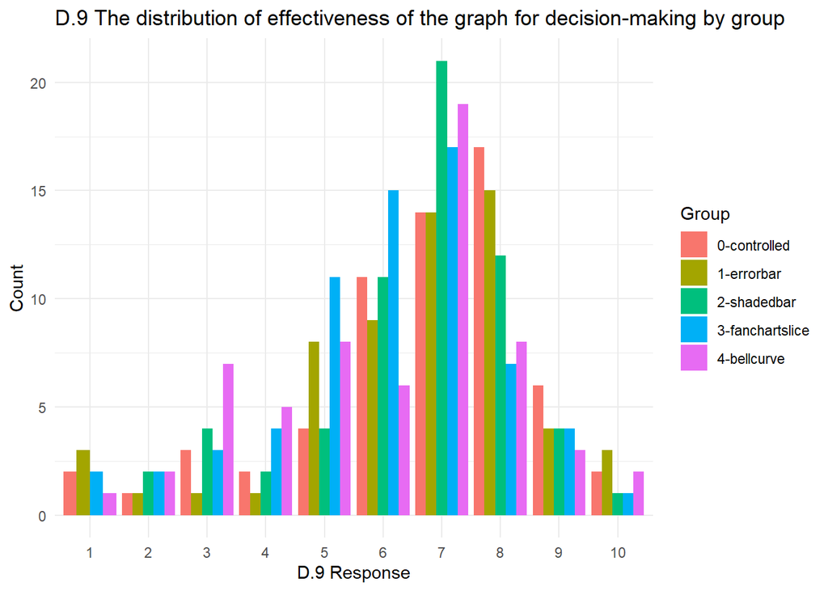

```r
# Grouped bar-style histogram
ggplot(survey_d9, aes(x = factor(d9_value), fill = factor(group))) +
  geom_bar(position = "dodge") +
  # facet_wrap(~ group) +
  labs(
    title = "D.9 The distribution of effectiveness of the graph for decision-making by group",
    x = "D.9 Response",
    y = "Count",
    fill = "Group"
  ) +
  theme_minimal()
```

## ? D.12 Skewed Investment Decision

Which bond would you choose to invest in?  
Variable: categorical  
Method: contingency table & chi-squared test  
**Result: There is significant difference in at least one group.**

```r
# combine data from different groups
survey_d12 <- data.frame()
survey_d12_list <- list("Q7.12", "Q9.12", "Q11.12", "Q13.12")
for (i in seq_along(skewed_group_list)) {
  df <- skewed_group_list[[i]]
  col <- survey_d12_list[[i]]
  temp_table <- df[, c(col, "group")]
  names(temp_table) <- c("d12_value", "group")
  survey_d12 <- rbind(survey_d12, temp_table)
}
survey_d12$d12_value <- as.numeric(survey_d12$d12_value)
```

Contingency table

```r
survey_d12_contingency <- table(survey_d12$d12_value, survey_d12$group)
print(survey_d12_contingency)
```

```
##
##     1-errorbar 2-shadedbar 3-fanchartslice 4-bellcurve
##   1          8          21              25           8
##   2         51          40              41          53
```

```r
# run chi-squared test
chisq_result <- chisq.test(survey_d12_contingency)
# print(chisq_result)
std_resid <- chisq_result$stdres
print(std_resid)
```

```
##
##     1-errorbar 2-shadedbar 3-fanchartslice 4-bellcurve
##   1  -2.343623    1.935627        2.796693   -2.488073
##   2   2.343623   -1.935627       -2.796693    2.488073
```

```r
# pairwise proportion test
pairwise.prop.test(
  x = survey_d12_contingency[2,],
  n = colSums(survey_d12_contingency),
  p.adjust.method = "bonferroni" # or "holm", "BH"
)
```

```
##
##  Pairwise comparisons using Pairwise comparison of proportions
##
## data:  survey_d12_contingency[2, ] out of colSums(survey_d12_contingency)
##
##                 1-errorbar 2-shadedbar 3-fanchartslice
## 2-shadedbar     0.084      -           -
## 3-fanchartslice 0.024      1.000       -
## 4-bellcurve     1.000      0.064       0.017
##
## P value adjustment method: bonferroni
```

Plot proportion bar plot across different groups

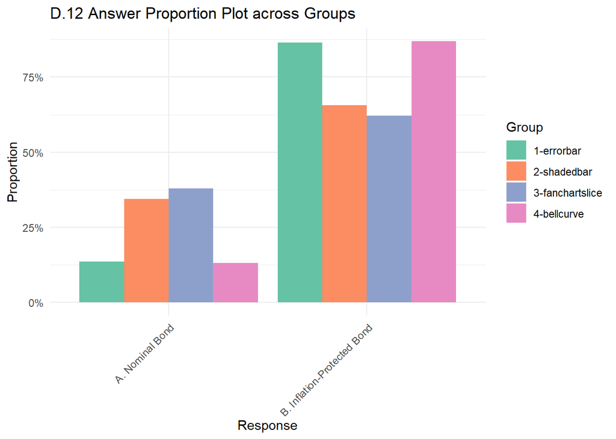

```r
survey_d12_prop  <- as.data.frame(survey_d12_contingency)
# rename columns
names(survey_d12_prop) <- c("D.12", "Group", "Count")
# add a labelled column
survey_d12_prop <- survey_d12_prop %>%
  mutate(D.12_label = case_when(
    D.12 == "1" ~ "A. Nominal Bond",
    D.12 == "2" ~ "B. Inflation-Protected Bond"
  ))
# calculate proportions within each group
survey_d12_prop <- survey_d12_prop %>%
  group_by(Group) %>%
  mutate(Proportion = Count / sum(Count))
ggplot(survey_d12_prop, aes(x = as.factor(`D.12_label`), y = Proportion, fill = Group)) + geom_col(position = "dodge") +
  # facet_wrap(~Group)+
  labs(
    title = "D.12 Answer Proportion Plot across Groups",
    x = "Response",
    y = "Proportion"
  ) +
   scale_fill_brewer(palette = "Set2")+
  scale_y_continuous(labels = scales::percent_format(accuracy = 1)) +
  theme_minimal()+
  theme(axis.text.x = element_text(angle = 45, hjust = 1))
```

Plot pie chart including all participants

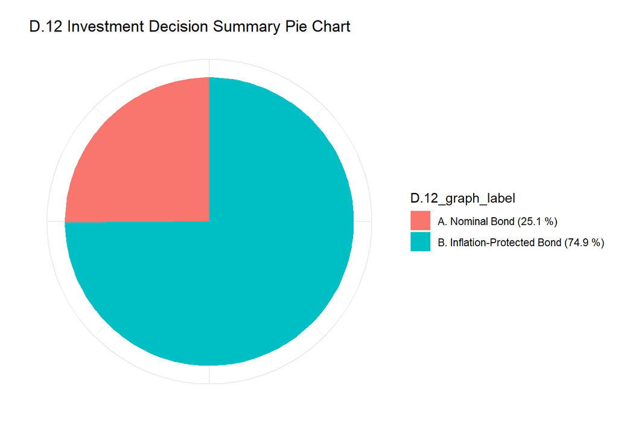

```r
survey_d12_summary <- survey_d12_prop %>%
  group_by(`D.12_label`) %>%
  summarise(total_count = sum(Count), .groups = "drop") %>%
  mutate(proportion = total_count / sum(total_count),
         `D.12_graph_label` = paste0(`D.12_label`, " (", round(proportion * 100, 2), " %)"))
ggplot(survey_d12_summary, aes(x = "",y = proportion, fill = `D.12_graph_label`)) +
  geom_col(width = 1) +
  coord_polar(theta = "y") +
  labs(title = "D.12 Investment Decision Summary Pie Chart",
       x = "",
       y = "") +
  theme_minimal() +
  theme(axis.text.x = element_blank())
```

## D.13 Skewed Confidentce in decision-making On a scale of 1 to 10, where 1 means not confident at all and 10 means very confident, how confident are you in making the decision?  
*1-Not confident at all; 10-Very confident*  
Variable: continuous  
Method: ANNOVA test or KW test (depends on whether it’s normally distributed)  
**Result: Fail to reject the null hypothesis.**

```r
# combine data from different groups
survey_d13 <- data.frame()
survey_d13_list <- list("Q7.13_1", "Q9.13_1", "Q11.13_1", "Q13.13_1")
for (i in seq_along(skewed_group_list)) {
  df <- skewed_group_list[[i]]
  col <- survey_d13_list[[i]]
  temp_table <- df[, c(col, "group")]
  names(temp_table) <- c("d13_value", "group")
  survey_d13 <- rbind(survey_d13, temp_table)
}
survey_d13$d13_value <- as.numeric(survey_d13$d13_value)
```

Statistical test

```r
# Initial Check
# summary(survey_d13$d13_value)
# check normality --> the data is not normally distributed
# shapiro.test(survey_d13$d13_value)

# run Kruskal-Wallis test
kruskal_test <- kruskal.test(d13_value ~ group, data = survey_d13)
print(kruskal_test)
```

```
##
##  Kruskal-Wallis rank sum test
##
## data:  d13_value by group
## Kruskal-Wallis chi-squared = 3.1127, df = 3, p-value = 0.3746
```

Summary statistics

```r
# Summary statistics
survey_d13_summary <- survey_d13 %>%
  group_by(group) %>%
  summarise(
    mean = mean(d13_value, na.rm = TRUE),
    median = median(d13_value, na.rm = TRUE),
    sd = sd(d13_value, na.rm = TRUE)
  )
```

Plot the distribution of different groups

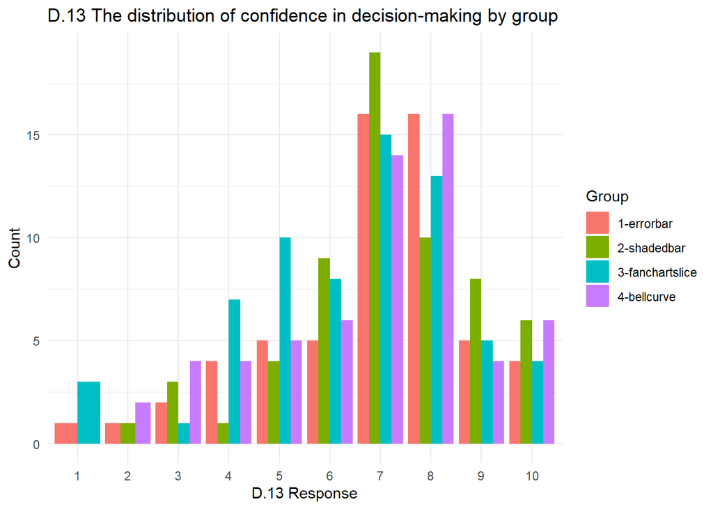

```r
# Grouped bar-style histogram
ggplot(survey_d13, aes(x = factor(d13_value), fill = factor(group))) +
  geom_bar(position = "dodge") +
  # facet_wrap(~ group) +
  labs(
    title = "D.13 The distribution of confidence in decision-making by group",
    x = "D.13 Response",
    y = "Count",
    fill = "Group"
  ) +
  theme_minimal()
```

# Cross-tabulation

## Current Inflation Knowledge vs. Inflation Forecast Knowledge

## Skewed Data vs. Unskewed Data ( understanding and decision making)

## For people who can correctly understand the probability (? which), what decision do they make?

## Does familarity with the graph type affect understanding and the decision?

# Statistical Testing

## Basics

```r
library(pwr)
N_total <- 309
sens <- pwr.anova.test(k = 5,
                       n = N_total / 5*1.15,   # ~10–15 % cushion for KW test
                       sig.level = 0.05,
                       power = 0.80)      # f left NULL
sens
```

```
##
##      Balanced one-way analysis of variance power calculation
##
##               k = 5
##               n = 71.07
##               f = 0.1845159
##       sig.level = 0.05
##           power = 0.8
##
## NOTE: n is number in each group
```

## Chi-squared test

### Post-hoc test

1. Standardized residuals

Cells with absolute value > ~2 (or > 1.96 for 95% confidence)indicate contributing most to the overall chi-squared

2. Pairwise proportion tests: can only compare one value

## ANOVA test

ANOVA only compares the means of the groups.  
### Assumptions of ANOVA 1. Normality of residuals within each group: If p-value<0.05, the data is not normally distributed

[output not shown]